# Assignment 5: Mixed models

Marton Kovacs / Zoltan Kekecs

# Introduction

This assignment is related to the previous lab assignment concerning perioperative pain and its psychological and hormonal predictors. Just like previously, you will set up linear model to predict postoperative pain after wisdom tooth surgery, but this time you will have to also take into account the fact that there is clustering in the data.

As a reminder, here is the protocol for data collection: “You have collected data from adults who were scheduled to undergo surgical extraction of the third mandibular molar (wisdom tooth surgery). Patients filled out a form in the waiting room before their surgery. The form contained questions about their sex, age, and weight, and psychological questionnaires assessing anxiety, pain catastrophizing, and mindfulness (see descriptions below). You also got blood samples and saliva samples from participants in the waiting room 5 minutes before their operations to determine the serum (a component of the blood) and salivary cortisol levels of participants. Participants were contacted 5 hours after the surgery to see how much pain they were experiencing. The **level of pain** at that moment was recorded using a numerical rating scale using a **scale of 0 to 10**, where 0 means “no pain” and 10 means “worst pain I can imagine”.

**The State Trait Anxiety Inventory:** T measures trait anxiety on a scale of 20 to 80, higher scores mean higher anxiety. Anxiety has been found in many studies to positively correlate with the level of pain experienced. This is **variable STAI_trait** in the dataset.

**The Pain Catastrophizing Scale** measures the extent of pain catastrophizing, which is characterized by a tendency to magnify the threat value of a pain stimulus and to feel helpless in the presence of pain, as well as by a relative inability to prevent or inhibit pain-related thoughts in anticipation of, during, or following a painful event. The total score on this scale ranges from 0 to 52, higher scores mean higher catastrophizing. Pain catastrophizing is one of the well-established predictors of clinical pain. This is **variable pain_cat** in the dataset.

**The Mindful Attention Awareness Scale (MAAS)** measures dispositional mindfulness, which may be described as a tendency to turn attention to present-moment experiences in an open, non-judgemental way. The MAAS total score ranges from 1 to 6 (an average of the item scores), with higher scores representing higher dispositional mindfulness. Trait mindfulness has been theorized to serve as a protective factor against pain, as the individual would be more objective about their pain experience and tend to associate less discomfort, despair, and hopelessness to the pain-related sensations. This is **variable mindfulness** in the dataset.

**Cortisol** is a stress hormone associated with acute and chronic stress. Cortisol levels are thought to be positively associated with pain experience. Cortisol can be **measured from both blood and the saliva**, although, serum cortisol is often regarded in medical research as more reliably related to stress (serum is a component of the blood plasma). These are **variables cortisol_serum**, and **cortisol_saliva** in the dataset.”

# Datasets

You will need two datasets for this assignment, datafile A and B. You can load them from the ‘data/’ folder.

# Task

First, fit a linear mixed model to estimate postoperative pain on datafile A. You should use the same fixed effect predictors as you used in your final model in the 3 assignment. (If you did not do that assignment, use the following predictors: age, sex, STAI, pain catastrophizing, mindfulness, and serum cortisol.) Importantly, the model has to account for the clustering of the data in different hospital sites. We have no reason to assume that the effects of the different predictors would be different in the different hospitals, so fit a random intercept model including the random intercept of hospital-ID. Once the model is built, note the model coefficients and the confidence intervals of the coefficients for all fixed effect predictors, and compare them to the ones obtained in the 3 assignment.

Also, compute the variance explained by the fixed effect predictors using marginal R<sup>2</sup>, and the variance explained by the fixed and random effect terms combined using conditional R<sup>2</sup>. Now use the model coefficients obtained on data file A to predict pain in datafile B.

**IMPORTANT:** Do not fit the regression models on data file B (don’t re-train your models), just use the regression equation you derived based on datafile A. These regression equations should be applied on the new data (datafile B), to predict pain.

Now compute the variance explained by the model on datafile B. You can do this by using the formula: **1 - (RSS / TSS) = R^2**. Compare this R<sup>2</sup> to the marginal and conditional R<sup>2</sup> values computed for the model on datafile A.

# What to report

Report the model coefficients and the confidence intervals of the coefficients for each fixed effect predictor obtained on data file A in a table.

Report the variance components for the fixed effects, the random intercept, and the residuals (from the model on data file A). Also report the marginal R<sup>2</sup> and the conditional R<sup>2</sup> squared obtained from the model on data file A, and the observed R<sup>2</sup> of this model for data file B.

# What to discuss

Compare the model coefficients and the confidence intervals observed in this assignment and the assignment for Lab 2 and discuss what you think the differences or similarities mean.

# Solution

## Read the data

Read the datasets used in this assignment. Pay attention to the extensions of the datafiles.

```r
install.packages("foreign")
library(foreign)
dataA <- read.spss("C:/Users/ferge/Documents/elte-ppk-r-course-Fall-2025-arion012/data/assignment_4_dataset_A.sav", to.data.frame = TRUE)
dataB <- read.spss("C:/Users/ferge/Documents/elte-ppk-r-course-Fall-2025-arion012/data/assignment_4_dataset_B.sav", to.data.frame = TRUE)
```

## Exploratory data analysis

Run an exploratory data analysis (EDA) to investigate the dataset.

```r
summary(dataA)
```

```
##       ID                 pain            sex                 age
##  Length:200         Min.   : 0.000   Length:200         Min.   :28.00
##  Class :character   1st Qu.: 4.000   Class :character   1st Qu.:37.00
##  Mode  :character   Median : 5.000   Mode  :character   Median :40.00
##                     Mean   : 4.845                      Mean   :39.99
##                     3rd Qu.: 6.000                      3rd Qu.:43.00
##                     Max.   :10.000                      Max.   :51.00
##    STAI_trait       pain_cat     cortisol_serum  cortisol_saliva
##  Min.   :24.00   Min.   :17.00   Min.   :1.640   Min.   :2.090
##  1st Qu.:36.00   1st Qu.:28.00   1st Qu.:4.290   1st Qu.:4.175
##  Median :40.00   Median :30.00   Median :4.970   Median :4.965
##  Mean   :39.66   Mean   :29.98   Mean   :4.914   Mean   :4.901
##  3rd Qu.:43.00   3rd Qu.:33.00   3rd Qu.:5.540   3rd Qu.:5.580
##  Max.   :52.00   Max.   :41.00   Max.   :7.630   Max.   :7.910
##   mindfulness        weight            IQ         household_income
##  Min.   :1.000   Min.   :38.80   Min.   : 59.00   Min.   : -2672
##  1st Qu.:2.265   1st Qu.:62.42   1st Qu.: 90.00   1st Qu.: 51175
##  Median :2.910   Median :69.55   Median :100.00   Median : 66268
##  Mean   :2.998   Mean   :69.57   Mean   : 99.86   Mean   : 68755
##  3rd Qu.:3.830   3rd Qu.:75.58   3rd Qu.:110.00   3rd Qu.: 87047
##  Max.   :5.580   Max.   :93.08   Max.   :148.00   Max.   :151242
##    hospital
##  Length:200
##  Class :character
##  Mode  :character
##
##
##
```

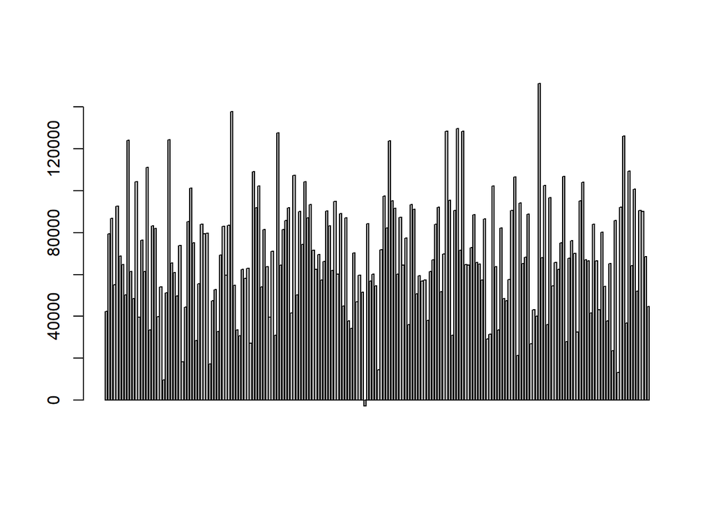

```r
barplot(dataA$household_income)
```

```r
sapply(dataA, function(x) sum(is.na(x)))
```

```
##               ID             pain              sex              age
##                0                0                0                0
##       STAI_trait         pain_cat   cortisol_serum  cortisol_saliva
##                0                0                0                0
##      mindfulness           weight               IQ household_income
##                0                0                0                0
##         hospital
##                0
```

```r
summary(dataB)
```

```
##       ID                 pain           sex                 age
##  Length:200         Min.   :0.000   Length:200         Min.   :25.00
##  Class :character   1st Qu.:4.000   Class :character   1st Qu.:36.00
##  Mode  :character   Median :5.000   Mode  :character   Median :39.50
##                     Mean   :5.205                      Mean   :39.64
##                     3rd Qu.:6.000                      3rd Qu.:43.00
##                     Max.   :9.000                      Max.   :52.00
##    STAI_trait       pain_cat     cortisol_serum  cortisol_saliva
##  Min.   :27.00   Min.   :19.00   Min.   :2.440   Min.   :2.610
##  1st Qu.:37.00   1st Qu.:28.00   1st Qu.:4.357   1st Qu.:4.372
##  Median :40.00   Median :30.00   Median :5.265   Median :5.165
##  Mean   :40.06   Mean   :30.57   Mean   :5.145   Mean   :5.130
##  3rd Qu.:44.00   3rd Qu.:34.00   3rd Qu.:5.923   3rd Qu.:5.843
##  Max.   :52.00   Max.   :44.00   Max.   :7.470   Max.   :7.480
##   mindfulness        weight             IQ         household_income
##  Min.   :1.000   Min.   : 44.62   Min.   : 62.00   Min.   :   304
##  1st Qu.:2.230   1st Qu.: 63.38   1st Qu.: 88.75   1st Qu.: 54669
##  Median :2.935   Median : 70.22   Median :100.00   Median : 68563
##  Mean   :2.933   Mean   : 70.33   Mean   : 99.09   Mean   : 70953
##  3rd Qu.:3.695   3rd Qu.: 77.52   3rd Qu.:110.00   3rd Qu.: 89486
##  Max.   :5.810   Max.   :103.46   Max.   :135.00   Max.   :148251
##    hospital
##  Length:200
##  Class :character
##  Mode  :character
##
##
##
```

```r
sapply(dataB, function(x) sum(is.na(x)))
```

```
##               ID             pain              sex              age
##                0                0                0                0
##       STAI_trait         pain_cat   cortisol_serum  cortisol_saliva
##                0                0                0                0
##      mindfulness           weight               IQ household_income
##                0                0                0                0
##         hospital
##                0
```

## Correct coding errors

If you find values in the dataset during the EDA, that are not correct based on the provided descriptions of the variables of the dataset please correct them here.

```r
dataA[grep('-2672', dataA$household_income), ]
```

```
##        ID pain    sex age STAI_trait pain_cat cortisol_serum cortisol_saliva
## 96 ID_96     5 female  42         46       29           4.81            5.27
##    mindfulness weight IQ household_income    hospital
## 96        1.51  77.44 93            -2672 hospital_5
```

```r
dataA[96, 12] <- 2672
summary(dataA$household_income)
```

```
##    Min. 1st Qu.  Median    Mean 3rd Qu.    Max.
##    2672   51175   66268   68782   87047  151242
```

```r
dataA = dataA %>%
mutate(sex = factor(recode(sex,
"1" = "man",
"0" = "woman")))

dataB = dataB %>%
mutate(sex = factor(recode(sex,
"1" = "man",
"0" = "woman")))
```

## Old regression modell on dataA

```r
old_model <- lmer(pain ~ age + sex + STAI_trait + mindfulness + cortisol_serum + (1 | hospital), data = dataA)
summary(old_model)
```

```
## Linear mixed model fit by REML ['lmerMod']
## Formula: pain ~ age + sex + STAI_trait + mindfulness + cortisol_serum +
##     (1 | hospital)
##    Data: dataA
##
## REML criterion at convergence: 676.6
##
## Scaled residuals:
##      Min       1Q   Median       3Q      Max
## -3.12609 -0.65397  0.02929  0.68067  2.80234
##
## Random effects:
##  Groups   Name        Variance Std.Dev.
##  hospital (Intercept) 0.3011   0.5488
##  Residual             1.5009   1.2251
## Number of obs: 200, groups:  hospital, 10
##
## Fixed effects:
##                Estimate Std. Error t value
## (Intercept)     4.47787    1.15621   3.873
## age            -0.06165    0.01918  -3.215
## sexmale         0.39210    0.17922   2.188
## sexMale        -0.10344    1.26020  -0.082
## STAI_trait      0.01463    0.02208   0.663
## mindfulness    -0.32451    0.08857  -3.664
## cortisol_serum  0.61810    0.11478   5.385
##
## Correlation of Fixed Effects:
##             (Intr) age    sexmal sexMal STAI_t mndfln
## age         -0.594
## sexmale     -0.071 -0.123
## sexMale      0.016  0.009  0.062
## STAI_trait  -0.426 -0.243  0.090 -0.090
## mindfulness -0.414 -0.088  0.119  0.004  0.281
## cortisl_srm -0.318  0.295 -0.035  0.072 -0.494  0.045
```

```r
confint(old_model)
```

```
## Computing profile confidence intervals ...
```

```
##                      2.5 %      97.5 %
## .sig01          0.28298377  0.93333490
## .sigma          1.09401838  1.33817290
## (Intercept)     2.24868190  6.73495937
## age            -0.09958978 -0.02469505
## sexmale         0.04664124  0.74380963
## sexMale        -2.55884755  2.33012706
## STAI_trait     -0.02815175  0.05744177
## mindfulness    -0.49605502 -0.15274685
## cortisol_serum  0.39598053  0.84092435
```

```r
model_performance(old_model)
```

```
## # Indices of model performance
##
## AIC   |  AICc |   BIC | R2 (cond.) | R2 (marg.) |   ICC |  RMSE | Sigma
## -----------------------------------------------------------------------
## 694.6 | 695.5 | 724.3 |      0.428 |      0.314 | 0.167 | 1.181 | 1.225
```

```r
cAIC(old_model)$caic
```

```
## [1] 665.8065
```

```r
results_old <- cbind(old_model, confint(old_model))
```

```
## Computing profile confidence intervals ...
```

```r
results_old <- results_old[-c(1, 2), ]
results_old <- cbind(results_old, fixef(old_model))
view(results_old)
```

## Results

The intercept of the model is 4.47, the fixed coefficents are age (-0,06) (CI: -0.09958978 -0.02469505), sexmale (0.39210) (CI: 0.04664124 0.74380963), sexMale (-0.10344) (CI: -2.55884755 2.33012706), STAI_trait (0.01463) (CI:-0.02815175 0.05744177), mindfulness (-0.32451) (CI: -0.49605502 -0.15274685) and cortisol_serum (0.61810) (CI: 0.39598053 0.84092435 ). Variance for the random intercept model for hospitals has an explanation for variance of 0.3011, which is a moderate effect on the outcome. The models intercept is 4.47787.

The results for the 3rd assigment: Intercept 4.26860, age -0.05996, sexmale 0.39433, sexwoman -0.35991, STAI_trait 0.02077, mindfulness -0.25702, cortisol_serum 0.59165.

The two modell has similar outcomes, with little difference in the coefficents of the male gender, mindfulness, STAI_trait and cortisol_serum. Marginal R^2 is 0.314 so the, while conditional R^2 is 0.428, which means if I’m right that the fixed effect explains 0.314 of the variance while with the random predictors the explained variance is 0.428.

## Old regression modell on dataB

```r
predictionB = predict(old_model, newdata = dataB, allow.new.levels = TRUE)

dataB <- cbind(dataB, predictionB)
residuals <- dataB$pain - dataB$predictionB
RSS <- sum(residuals^2)
RSS
```

```
## [1] 311.974
```

```r
mean_pain <- mean(dataB$pain)
TSS <- sum((dataB$pain - mean_pain)^2)
predB_R2 = 1 - (RSS/TSS)
predB_R2
```

```
## [1] 0.3226718
```

## Discussuion

The model got an R^2 of 0.3226718 being ran on the second model, which is quite low. Compared to the conditional R^2 on data set A which was 0.428. But quite similar to the Margival R^2 which was 0.314. In the original setting in assigment 3 it got a R^2 of 0.27 which is lower compared to these outcomes. This upgrade in the mixed model can derive from taking in consideration the clustering of hospitals and acting on it by letting each one have its own intercept. While in the older model it wasn’t considered and this addition raises the R^2 to a higher level.

The intercept correlated negatively with most fixed effects (mostly with age -0.594, mindfulness -0.414 and STAI_trait - 0.426), Yet comparing the confidence intervals of the two research reveals that there are minor differences between the effect of the same random predictor groups which means that the effect is not based necessarily on hospital care and is part of a trend which is quite stable across multiple samples.

Honorable mention of predictors are the age (-0,05)(-0.06) which has low effect yet is significant. STAI on the contrary is neither impactful (0.02)(0.01) neither significant.